# Examen_a_casa_aplicacion_de_GMLR_Ibarra_try4

SIR

2023-11-24

### UNAM Posgrado en Ingeniería

### Dr. Wulfrano Gomez Gallardo

### Alumno: Ibarra Ramírez Sergio

### Ejemplo de aplicación de modelos Lineales Generalizados (GLR Ó MCG) en el pronóstico de sueldos

#### La prueba estadística F(Fisher) para evaluación de valor general constante para todos los elementos del vecotr ${\beta}$

Donde la H0: El vector ${\beta}$ es igual a un valor determinado para todos sus elementos, por ejemplo ${\beta}=r$ donde r=0

$$\begin{cases}
H_0&: \boldsymbol{\beta} = \boldsymbol{r}\\
H_1&: \boldsymbol{\beta} \neq \boldsymbol{r}
\end{cases}$$

Donde se asume que ambos errores a) Error explicado por el modelo con k grados de libertad / b) Error no explicado por el modelo (error estocástico) con n-k grados de libertad siguen una distribución t de student para una determinada muestra y por lo tanto, el cociente de ambas cantidades pueden intepretarse como un estadístico F de fisher con K,N-K grados de libertado:

$$F = \dfrac{
\left(\widehat{\boldsymbol{\beta}}_{GLS} - \boldsymbol{r} \right)^\top
\left[\left( \mathbf{X}^\top \mathbf{\Omega}^{-1}
\mathbf{X} \right)\right]^{-1} \left(
\widehat{\boldsymbol{\beta}}_{GLS} - \boldsymbol{r}
\right)}{\widehat{\epsilon}^2} \sim F_{(K, N - K)}$$

#### Las pruebas estadística T(student) para evaluación de valor individual de cada elemento del vecotr ${\beta}$

Donde la H0: El i-esimo elemento del vector ${\beta}$ es igual a un valor determinado , por ejemplo ${\beta_{i}}=r$ donde puede ser cero r=0 ç

$$\begin{cases}
H_0&: \boldsymbol{\beta_{j}} = \boldsymbol{r}\\
H_1&: \boldsymbol{\beta_{j}} \neq \boldsymbol{r}
\end{cases}$$

Si $\gamma_{j}$ es el j-esimo coeficiente diagonal de la matriz $\left ( X^{T} X \right )^{-1}$ y $\gamma_{j}>0$

Entonces el valor de t estadistico de prueba para cada $\beta_{j}$ es:

$$t_{n-k}=\frac{\widehat\beta_{j} -
\beta_{j} }{\sqrt{\sigma^{2} \gamma_{j}}}$$

#### El modelo General Lineal Simple o Modelo de Mínimos Cuadrados Ordinarios

Consideremos al modelo de regresión lineal simple o modelo de Mínimos Cuadrados Ordinarios (OMS ó MCO) como:

$$\begin{align}
\mathbf{Y} = \mathbf{X} \boldsymbol{\beta} + \boldsymbol{\varepsilon}
\end{align}$$

Donde:  
Y: Vector de valores estimados  
X: Matriz ampliada de valores de las variables independientes xi  
$\beta$: Vector de estimadores de maxima verosimilitud calculado con el modelo MCO

El cual asume:

$$Y |X \sim \operatorname{N}(\mu(X),
\sigma^2I)$$

Donde:  
Y: Vector de valores estimados  
X: Matriz ampliada de valores de las variables independientes xi  
$\mu(X)$ is the mean of the normal distribution, which is a function of X  
$\sigma^2I$ is the variance of the normal distribution, where I is the identity matrix.

Y por lo tanto:

$$E(Y |X) = \mu(X) =
\mathbf{X}^\top\boldsymbol{\beta}$$

### Ejemplo de aplicación de GLM

```r
library(lmtest)
library(lrmest)
library(tseries)
library(nortest)
##library(car)
library(sandwich)
library(lattice)
library(viridisLite)
library(leaps)
```

#### Importación y lectura de la data para el modelo GLM

```r
wage_source <- "http://www.principlesofeconometrics.com/poe5/data/csv/cps5_small.csv"
wage_data <- read.csv(file = wage_source, sep = ",", dec = ".", header = TRUE)
print(head(wage_data, 10))
```

```
##    black educ exper faminc female metro midwest south  wage west
## 1      0   13    45      0      1     1       0     0 44.44    1
## 2      0   14    25  45351      1     1       1     0 16.00    0
## 3      0   18    27  91946      1     1       0     0 15.38    0
## 4      0   13    42  48370      0     1       1     0 13.54    0
## 5      0   13    41  10000      1     1       0     0 25.00    1
## 6      0   16    26 151308      1     1       0     0 24.05    0
## 7      0   16    11 110461      1     1       0     1 40.95    0
## 8      0   18    15      0      1     1       1     0 26.45    0
## 9      0   21    32  67084      0     1       1     0 30.76    0
## 10     0   14    12  14000      0     0       0     0 34.57    1
```

Definiciones de variables:

black - = 1 si es negro educ - años de educación exper - experiencia potencial = edad - educación - 6 faminc - otros ingresos familiares, $ female - = 1 si es mujer metro - = 1 si se encuentra en un área metropolitana midwest - = 1 si es región del medio oeste south - = 1 si es región sur wage - ingresos por hora, $ west - = 1 si es región oeste

Tengamos un vistazo rápido de los datos con un reumen estadístico de las variables

```r
print(summary(wage_data))
```

```
##      black             educ          exper           faminc
##  Min.   :0.0000   Min.   : 0.0   Min.   : 0.00   Min.   :     0
##  1st Qu.:0.0000   1st Qu.:12.0   1st Qu.:12.00   1st Qu.:     0
##  Median :0.0000   Median :14.0   Median :24.00   Median : 23679
##  Mean   :0.0875   Mean   :14.2   Mean   :23.37   Mean   : 35304
##  3rd Qu.:0.0000   3rd Qu.:16.0   3rd Qu.:34.00   3rd Qu.: 53029
##  Max.   :1.0000   Max.   :21.0   Max.   :62.00   Max.   :469000
##      female         metro           midwest           south
##  Min.   :0.00   Min.   :0.0000   Min.   :0.0000   Min.   :0.000
##  1st Qu.:0.00   1st Qu.:1.0000   1st Qu.:0.0000   1st Qu.:0.000
##  Median :0.00   Median :1.0000   Median :0.0000   Median :0.000
##  Mean   :0.44   Mean   :0.8217   Mean   :0.2475   Mean   :0.325
##  3rd Qu.:1.00   3rd Qu.:1.0000   3rd Qu.:0.0000   3rd Qu.:1.000
##  Max.   :1.00   Max.   :1.0000   Max.   :1.0000   Max.   :1.000
##       wage             west
##  Min.   :  3.94   Min.   :0.0000
##  1st Qu.: 13.00   1st Qu.:0.0000
##  Median : 19.30   Median :0.0000
##  Mean   : 23.64   Mean   :0.2525
##  3rd Qu.: 29.80   3rd Qu.:1.0000
##  Max.   :221.10   Max.   :1.0000
```

#### División de la data en train & test

```r
# Set seed for reproducibility
set.seed(123)

# Create an index for splitting the data
index <- sample(2, nrow(wage_data), replace = TRUE, prob = c(0.8, 0.2))

# Split the data into training and test sets
wage_train_data <- wage_data[index == 1, ]
wage_test_data <- wage_data[index == 2, ]

print(head(wage_test_data))
```

```
##    black educ exper faminc female metro midwest south  wage west
## 4      0   13    42  48370      0     1       1     0 13.54    0
## 5      0   13    41  10000      1     1       0     0 25.00    1
## 8      0   18    15      0      1     1       1     0 26.45    0
## 11     0   18     8      0      1     1       0     1 20.67    0
## 16     0   16    33  63169      0     1       0     0 11.00    1
## 20     0   14     5  77280      1     1       0     1 11.50    0
```

#### A. Las variables xi predictoras son linealmente indpendientes entre si, por lo que la matriz X es de rango completo

```r
panel.hist <- function(x, ...){
    usr <- par("usr"); on.exit(par(usr))
    par(usr = c(usr[1:2], 0, 1.5) )
    h <- hist(x, plot = FALSE, breaks = 30)
    breaks <- h$breaks; nB <- length(breaks)
    y <- h$counts; y <- y/max(y)
    rect(breaks[-nB], 0, breaks[-1], y, ...)
}
panel.abs_cor <- function(x, y, digits = 2, prefix = "", cex.cor, ...){
    usr <- par("usr"); on.exit(par(usr))
    par(usr = c(0, 1, 0, 1))
    r <- abs(cor(x, y, use = "complete.obs"))
    txt <- format(c(r, 0.123456789), digits = digits)[1]
    txt <- paste0(prefix, txt)
    if(missing(cex.cor)) cex.cor <- 0.8/strwidth(txt)
    text(0.5, 0.5, txt, cex = 2)
}
```

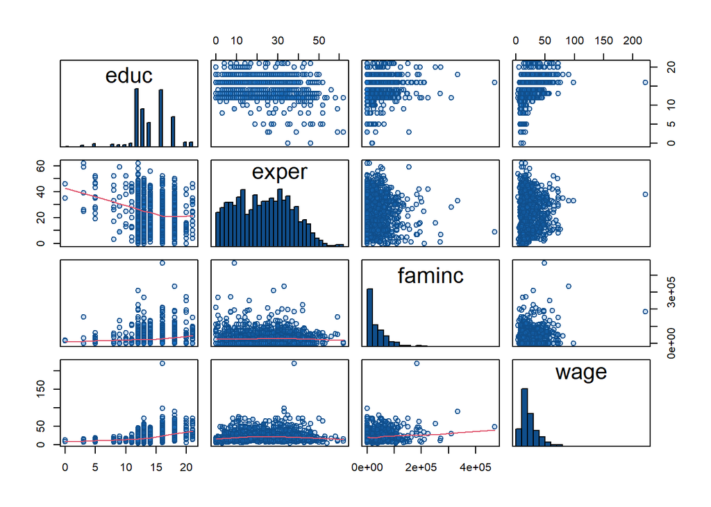

```r
pairs(wage_train_data[, c('educ','exper', 'faminc', 'wage')],
      diag.panel = panel.hist,
      lower.panel = panel.smooth, #upper.panel = panel.cor,
      col = "dodgerblue4",
      pch = 21,
      bg = adjustcolor("dodgerblue3", alpha = 0.2))
```

Los valores absolutos de la correlación son útiles para determinar la fuerza general de la relación lineal, independientemente de la dirección de la correlación.

También podemos estar interesados en verificar el mapa de calor de la matriz de correlación por separado

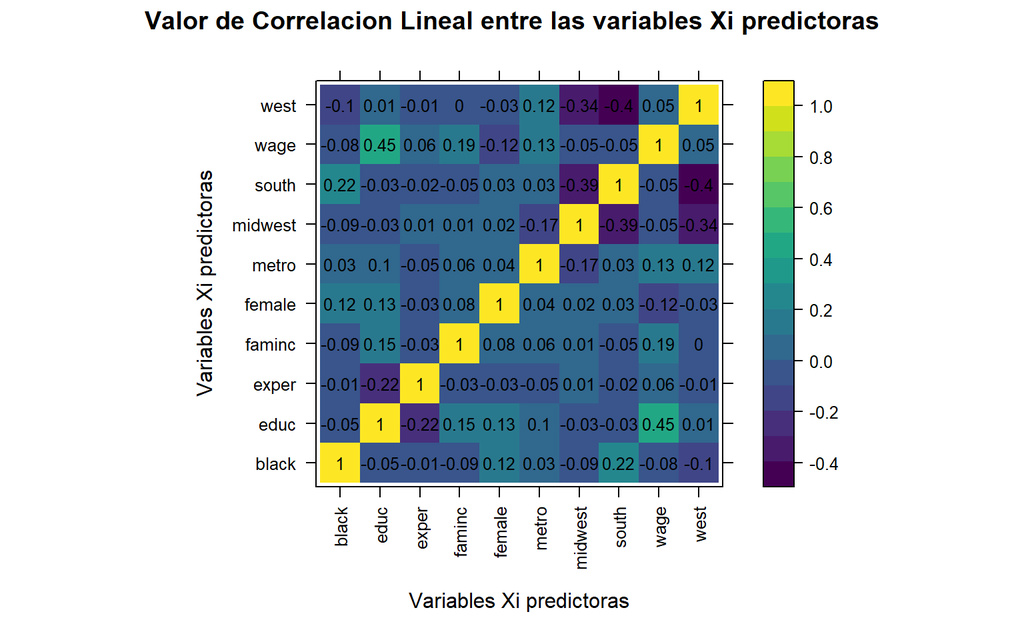

```r
myPanel <- function(x, y, z, ...){
  lattice::panel.levelplot(x, y, round(z, 2), ...)  # Round the correlation values to two decimals
  my_text <- ifelse(!is.na(z), paste0(round(z, 2)), "")
  lattice::panel.text(x, y, my_text, cex = 0.8)  # Adjust the font size
}
# base colors: terrain.colors(), rainbow(), heat.colors(), topo.colors() or cm.colors()
# Viridis: viridis, magma, inferno, plasma
lattice::levelplot(cor(wage_train_data, use = "complete.obs"), panel = myPanel,
                   col.regions = viridisLite::viridis(100),
  main =("Valor de Correlacion Lineal entre las variables Xi predictoras"), ylab = list(label = "Variables Xi predictoras"),
                               xlab = list(label = "Variables Xi predictoras"), scales = list(x = list(rot = 90)))  #)  # Rotate the x-axis labels by 90 degrees
```

Observamos queObservamos que wage y educ tienen una correlación positiva. Esta es la correlación positiva más fuerte en el conjunto de datos. south, midwest y west parecen estar negativamente correlacionados, sin embargo, es lo que se espera - son variables indicadoras de la ubicación geográfica, por lo que una observación solo puede tener una de estas variables con un valor de 1 1 a la vez.

### Modelo lineal simple SLM o MCO1 a para encontrar el error y hacer las pruebas de las hipotesis planteadas como ciertas para los modelos lineales

```r
# Load libraries
library(stats)

# Fit linear model
olm_model1_wage_train_data <- lm(wage ~ black+educ+exper+faminc+female+metro+midwest+south, data = wage_train_data)

# View model summary
summary(olm_model1_wage_train_data)
```

```
##
## Call:
## lm(formula = wage ~ black + educ + exper + faminc + female +
##     metro + midwest + south, data = wage_train_data)
##
## Residuals:
##     Min      1Q  Median      3Q     Max
## -31.449  -7.888  -2.275   4.952 180.870
##
## Coefficients:
##               Estimate Std. Error t value Pr(>|t|)
## (Intercept) -1.799e+01  2.692e+00  -6.682 3.98e-11 ***
## black       -1.144e+00  1.584e+00  -0.722  0.47045
## educ         2.545e+00  1.530e-01  16.639  < 2e-16 ***
## exper        1.945e-01  3.302e-02   5.892 5.28e-09 ***
## faminc       4.255e-05  9.571e-06   4.445 9.80e-06 ***
## female      -5.742e+00  8.836e-01  -6.499 1.30e-10 ***
## metro        3.483e+00  1.159e+00   3.006  0.00271 **
## midwest     -1.451e+00  1.098e+00  -1.322  0.18661
## south       -1.229e+00  1.028e+00  -1.196  0.23209
## ---
## Signif. codes:  0 '***' 0.001 '**' 0.01 '*' 0.05 '.' 0.1 ' ' 1
##
## Residual standard error: 13.38 on 960 degrees of freedom
## Multiple R-squared:  0.2835, Adjusted R-squared:  0.2776
## F-statistic: 47.49 on 8 and 960 DF,  p-value: < 2.2e-16
```

El modelo resultante de aplicar MOC1 a la data de wage fue:

$$\begin{aligned}
wage_i &= \beta_0 - \beta_1 black_i + \beta_2 educ_i + \beta_3
exper_i + \beta_4 faminc_i - \beta_5 female_i + \beta_6 metro_i -
\beta_7 midwest_i - \beta_8 south_i + \varepsilon_i ;
\\i = 1,...,N
\end{aligned}$$

#### Interpretación un modelo lineal simple SLM o MCO para pronóstico de salario con base en datos raciales, de genero y geográficos

Empezemos específicando el modelo resultante de aplicar el MCO a la data de wage como función de las (9-1) variables predictoras xi que componen el dataset original.

$$wage_i = -17.98 - 1.14*black_i +
2.54*educ_i + 0.19*exper_i + 0.00005*faminc_i - 5.74*female_i +
3.48*metro_i - 1.45*midwest_i - 1.22*south_i +
\varepsilon_i$$

Según el modelo estimado MCO1, se observa lo siguiente:

Los coeficientes son los esperados para las variables “educ”, “exper”: - Un año más de educación representa en promedio 2.54 más de ganancia - Un año más de experiencia representa en promedio 0.19 más de ganancia

El coeficiente de la variable “metro” también es el esperado: - Vivir en un área metropolitana representa en promedio 3.48 más de ganancia con respecto a no vivir en un área metropolitana

Para los coeficientes regionales de la variable “south” - Vivir en un área “south” representa en promedio 1.22 menos de ganancia con respecto a no vivir en un área “south”

El signo del coeficiente de la variable “female” es negativo y significativo, lo que indica una posible discriminación en la fuerza laboral (cabe recalcar que este es solo el modelo inicial, por lo que aún no podemos estar seguros). - Ser “Female” representa en promedio 5.7 menos de ganancia con respecto a no ser “Female”

El signo del coeficiente de la variable “black” es negativo, pero no tan grande como Female - Ser “Black” representa en promedio 1.14 menos de ganancia con respecto a no ser “Black”

#### Evaluación de la significancia de los estimadores $\beta$ del modelo MCO1

Queremos probar por separado la hipótesis de que cada coeficiente sea significativo a través de la prueba t de student que se presentó arriba

$$\begin{cases}
H_0&: \boldsymbol{\beta_{j}} = \boldsymbol{r}\\
H_1&: \boldsymbol{\beta_{j}} \neq \boldsymbol{r}
\end{cases}$$

```r
print(round(coef(summary(olm_model1_wage_train_data)), 4))
```

```
##             Estimate Std. Error t value Pr(>|t|)
## (Intercept) -17.9852     2.6915 -6.6822   0.0000
## black        -1.1438     1.5842 -0.7220   0.4705
## educ          2.5450     0.1530 16.6387   0.0000
## exper         0.1945     0.0330  5.8918   0.0000
## faminc        0.0000     0.0000  4.4453   0.0000
## female       -5.7423     0.8836 -6.4990   0.0000
## metro         3.4832     1.1587  3.0062   0.0027
## midwest      -1.4510     1.0979 -1.3216   0.1866
## south        -1.2287     1.0276 -1.1957   0.2321
```

#### Prueba de hipotesis global para el modelo MCO1

Recordar la prueba de hipotesis F de fisher sobre los errores explicados vs no explicados por el modelo

$$F = \dfrac{
\left(\widehat{\boldsymbol{\beta}}_{GLS} - \boldsymbol{r} \right)^\top
\left[\left( \mathbf{X}^\top \mathbf{\Omega}^{-1}
\mathbf{X} \right)\right]^{-1} \left(
\widehat{\boldsymbol{\beta}}_{GLS} - \boldsymbol{r}
\right)}{\widehat{\epsilon}^2} \sim F_{(K, N - K)}$$

Esta es la prueba de hipótesis conjunta para la significancia de múltiples coeficientes, aplicada a todos los coeficientes del modelo MCO:

$$\begin{cases}
H_0&: \beta_1 = \beta_2 = ... = \beta_k = 0 \\
H_1&: \beta_{j} \neq 0, \quad \text{for some } j
\end{cases}$$

En donde dicha F también puede ser expresada como:

$$F =
\dfrac{\text{ESS}/k}{\text{RSS}/(N-(k+1))} = \dfrac{R^2/k}{(1 -
R^2)/(N-(k+1))}$$

La prueba F de significación general compara un modelo sin predictores con el modelo especificado. Un modelo de regresión que no contiene predictores también se conoce como modelo de solo intersección, donde todos los valores ajustados son iguales a la media de la variable de respuesta. Por tanto, si el valor p de la prueba F general es menor que el nivel de significancia α, el modelo especificado predice la variable de respuesta mejor que la media de la respuesta.

```r
print(car::linearHypothesis(olm_model1_wage_train_data, c("black=0", "educ=0", "exper=0",  "faminc=0" ,  "female=0",  "metro=0",  "midwest=0",  "south=0")))
```

```
## Linear hypothesis test
##
## Hypothesis:
## black = 0
## educ = 0
## exper = 0
## faminc = 0
## female = 0
## metro = 0
## midwest = 0
## south = 0
##
## Model 1: restricted model
## Model 2: wage ~ black + educ + exper + faminc + female + metro + midwest +
##     south
##
##   Res.Df    RSS Df Sum of Sq      F    Pr(>F)
## 1    968 239896
## 2    960 171877  8     68020 47.489 < 2.2e-16 ***
## ---
## Signif. codes:  0 '***' 0.001 '**' 0.01 '*' 0.05 '.' 0.1 ' ' 1
```

Dado que el valor p es menor que 0.05 decido que tenemos sifuciente videncia para rechazar la HO y por lo tanto decir que los coeficientes $\beta$ del modelo MCO1 son diferentes de cero

### Modelo MCO2 (removiendo las variables que no resultaron significatrivas en el MCO1 “original” que incluía todas las variables predictoras xi del conjunto de datos como variables predictoras)

Para construir el MCO2 se removerán las variables cuyos coeficientes p en la prueba t del modelo MCO1 sean mayores a 0.05, es decir las variables no significativas para el modelo MCO1, que en este caso eran: black, midwest y south.

```r
# Load libraries
library(stats)

# Fit linear model
olm_model2_wage_train_data <- lm(wage ~ educ+exper+faminc+female+metro, data = wage_train_data)

# View model summary
summary(olm_model2_wage_train_data)
```

```
##
## Call:
## lm(formula = wage ~ educ + exper + faminc + female + metro, data = wage_train_data)
##
## Residuals:
##     Min      1Q  Median      3Q     Max
## -31.292  -7.820  -2.252   4.615 180.178
##
## Coefficients:
##               Estimate Std. Error t value Pr(>|t|)
## (Intercept) -1.927e+01  2.584e+00  -7.460 1.93e-13 ***
## educ         2.563e+00  1.526e-01  16.800  < 2e-16 ***
## exper        1.963e-01  3.300e-02   5.949 3.76e-09 ***
## faminc       4.357e-05  9.523e-06   4.575 5.38e-06 ***
## female      -5.902e+00  8.751e-01  -6.744 2.66e-11 ***
## metro        3.689e+00  1.140e+00   3.235  0.00126 **
## ---
## Signif. codes:  0 '***' 0.001 '**' 0.01 '*' 0.05 '.' 0.1 ' ' 1
##
## Residual standard error: 13.38 on 963 degrees of freedom
## Multiple R-squared:  0.2812, Adjusted R-squared:  0.2775
## F-statistic: 75.36 on 5 and 963 DF,  p-value: < 2.2e-16
```

El modelo resultante de aplicar MOC2 a la data de wage fue:

$$\begin{aligned}
wage_i &= \beta_0 - \beta_1 educ_i + \beta_2 exper_i + \beta_3
faminc_i - \beta_4 female_i + \beta_5 metro_i + \varepsilon_i
\\i = 1,...,N
\end{aligned}$$

#### Interpretación un modelo lineal simple SLM o MCO2 para pronóstico de salario con base en datos raciales, de genero y geográficos

Empezemos específicando el modelo resultante de aplicar el MCO2 a la data de wage fomo función de las 5 variables predicoras xi que resultaron significativas.

```r
print(round(coef(summary(olm_model2_wage_train_data)), 4))
```

```
##             Estimate Std. Error t value Pr(>|t|)
## (Intercept) -19.2749     2.5837 -7.4601   0.0000
## educ          2.5631     0.1526 16.7999   0.0000
## exper         0.1963     0.0330  5.9494   0.0000
## faminc        0.0000     0.0000  4.5753   0.0000
## female       -5.9016     0.8751 -6.7438   0.0000
## metro         3.6894     1.1403  3.2353   0.0013
```

#### Prueba de hipotesis global para el modelo MCO2

Esta es la prueba de hipótesis conjunta para la significancia de múltiples coeficientes, aplicada a todos los coeficientes del modelo MCO:

$$\begin{cases}
H_0&: \beta_1 = \beta_2 = ... = \beta_k = 0 \\
H_1&: \beta_{j} \neq 0, \quad \text{for some } j
\end{cases}$$

```r
print(car::linearHypothesis(olm_model2_wage_train_data, c("educ=0", "exper=0",  "faminc=0" ,  "female=0",  "metro=0")))
```

```
## Linear hypothesis test
##
## Hypothesis:
## educ = 0
## exper = 0
## faminc = 0
## female = 0
## metro = 0
##
## Model 1: restricted model
## Model 2: wage ~ educ + exper + faminc + female + metro
##
##   Res.Df    RSS Df Sum of Sq     F    Pr(>F)
## 1    968 239896
## 2    963 172429  5     67467 75.36 < 2.2e-16 ***
## ---
## Signif. codes:  0 '***' 0.001 '**' 0.01 '*' 0.05 '.' 0.1 ' ' 1
```

Dado que el valor p es menor que 0.05 decido que tenemos sifuciente videncia para rechazar la HO y por lo tanto decir que los coeficientes $\beta$ del modelo MCO2 son diferentes de cero

### Evaluación de los error del modelo MCO2 (verificación de pruebas de hipotesis de MCO)

Una vez teniendo el modelo MCO2 en el que todas las variables predcitoras xi son significativas se procederá a hacer las diferentes pruebas de hipitesis al error generado con el modelo MCO2 aplicado a los datos de entrenamiento, es decir, las pruebas de - Normalidad de los errores - No autocorrelación de orden 1 y ordenes superiroes de los errores - Homocerasticidad de errores

#### Evaluación general de los error del modelo MCO2

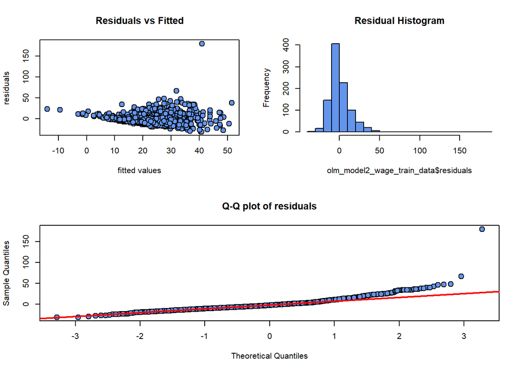

```r
# Define the plot layout matrix:
layout_mat <- matrix(c(1, 1, 2, 2, 3, 3, 3, 3),
                     nrow = 2, byrow = TRUE)
# print(layout_mat)
layout(layout_mat)
plot(olm_model2_wage_train_data$fitted.values, olm_model2_wage_train_data$residuals, type = "p",
     pch = 21, bg = "cornflowerblue", main = "Residuals vs Fitted",
     ylab = "residuals", xlab = "fitted values", cex = 1.5)
hist(olm_model2_wage_train_data$residuals, col = "cornflowerblue",
     breaks = 30, main = "Residual Histogram")
qqnorm(olm_model2_wage_train_data$residuals, main = "Q-Q plot of residuals",
       pch = 21, bg = "cornflowerblue", cex = 1.5)
qqline(olm_model2_wage_train_data$residuals, col = "red", lwd = 2)
```

#### Test de Homocedasticidad de errores del modelo MCO2 (Test Breusch-Pagan)

$$\begin{cases}
H_0&: \text{residuals are homoskedastic}\\
H_1&: \text{residuals are heteroskedastic}
\end{cases}$$

```r
# Breusch–Pagan Test

print(lmtest::bptest(olm_model2_wage_train_data))
```

```
##
##  studentized Breusch-Pagan test
##
## data:  olm_model2_wage_train_data
## BP = 27.149, df = 5, p-value = 5.335e-05
```

En este caso el valor de p< 0.05, por lo tanto rechazamos la hipótesis nula de que los residuos son homocedásticos. Esto significa que los residuos son heterocedásticos.

#### Test de Autocorrelación de errores del modelo MCO2 (Test Durbin-Watson, autocorrelación de 1er orden)

$$\begin{cases}
H_0&:\text{the errors are serially uncorrelated}\\
H_1&:\text{the errors are autocorrelated (the exact order of the
autocorrelation depends on the test carried out)}
\end{cases}$$

```r
# Durbin–Watson Test
print(lmtest::dwtest(olm_model2_wage_train_data, alternative = "two.sided"))
```

```
##
##  Durbin-Watson test
##
## data:  olm_model2_wage_train_data
## DW = 2.021, p-value = 0.7447
## alternative hypothesis: true autocorrelation is not 0
```

El estadístico de DW está cerca de 2 (esto se puede verificar en R, ya que el valor p asociado es mayor a 0.05), por lo que no rechazamos la hipótesis nula de que no existe correlación serial de orden 1.

#### Test de Autocorrelación de Parcial errores del modelo MCO2 (Test PACF, autocorrelación de orden superior)

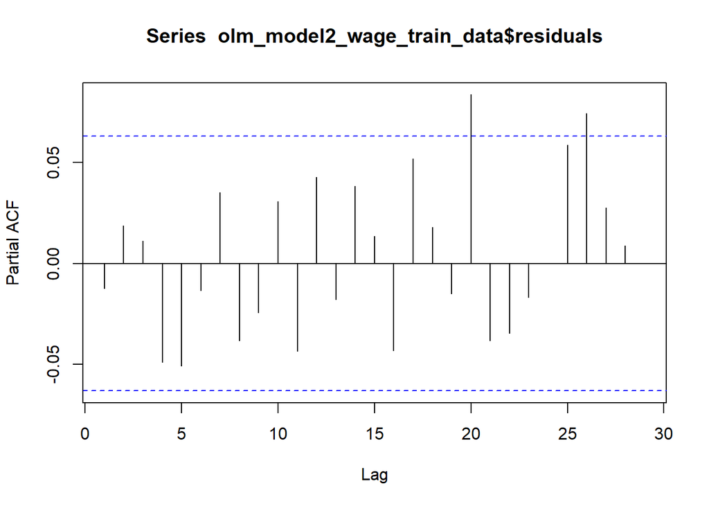

```r
pacf(olm_model2_wage_train_data$residuals)
```

#### Test de Normalidad de los errores del modelo MCO2 (Test Jarque-Bera)

$$\begin{cases}
H_0&:\text{residuals follow a normal distribution}\\
H_1&:\text{residuals do not follow a normal distribution}
\end{cases}$$

```r
 tseries::jarque.bera.test(olm_model2_wage_train_data$residuals)
```

```
##
##  Jarque Bera Test
##
## data:  olm_model2_wage_train_data$residuals
## X-squared = 50484, df = 2, p-value < 2.2e-16
```

A partir de estos resultados de la prueba, podemos decir que tenemos suficiente información para rechazar H0 y por lo tanto concluir que los residuos del modelo MCO2 NO se distribuyen normalmente :(

### Modelo MCO3 (removiendo las variables que no resultaron significatrivas en el MCO1 original que incluía todas las variables predictoras xi del conjunto de datos como variables predictoras + Logaritmo de variable dependiente wage como medida para lograr normalidad en error)

Para construir el MCO3 se removerán las variables cuyos coeficientes p en la prueba t del modelo MCO1 sean mayores a 0.05, es decir las variables no significativas para el modelo MCO1, que en este caso eran: black, midwest y south. Aedemás el modelo se hará tomadno como variable dependiente el log(wage)

```r
# Load libraries
library(stats)

# Fit linear model
olm_model3_wage_train_data <- lm(log(wage) ~ educ+exper+faminc+female+metro, data = wage_train_data)

# View model summary
summary(olm_model3_wage_train_data)
```

```
##
## Call:
## lm(formula = log(wage) ~ educ + exper + faminc + female + metro,
##     data = wage_train_data)
##
## Residuals:
##      Min       1Q   Median       3Q      Max
## -1.57091 -0.32398 -0.01449  0.29558  1.82559
##
## Coefficients:
##               Estimate Std. Error t value Pr(>|t|)
## (Intercept)  1.273e+00  8.941e-02  14.234  < 2e-16 ***
## educ         1.051e-01  5.280e-03  19.904  < 2e-16 ***
## exper        7.820e-03  1.142e-03   6.848 1.33e-11 ***
## faminc       1.014e-06  3.295e-07   3.077 0.002149 **
## female      -2.195e-01  3.028e-02  -7.250 8.58e-13 ***
## metro        1.346e-01  3.946e-02   3.412 0.000672 ***
## ---
## Signif. codes:  0 '***' 0.001 '**' 0.01 '*' 0.05 '.' 0.1 ' ' 1
##
## Residual standard error: 0.4631 on 963 degrees of freedom
## Multiple R-squared:  0.3343, Adjusted R-squared:  0.3308
## F-statistic: 96.71 on 5 and 963 DF,  p-value: < 2.2e-16
```

El modelo resultante de aplicar MOC3 a la data de wage fue:

$$\begin{aligned}
log(wage_i) &= \beta_0 - \beta_1 educ_i + \beta_2 exper_i + \beta_3
faminc_i - \beta_4 female_i + \beta_5 metro_i + \varepsilon_i
\\i = 1,...,N
\end{aligned}$$

Empezemos específicando el modelo resultante de aplicar el MCO3 a la data de log(wage) como función de las 5 variables predictoras xi que resultaron significativas.

```r
print(round(coef(summary(olm_model3_wage_train_data)), 4))
```

```
##             Estimate Std. Error t value Pr(>|t|)
## (Intercept)   1.2727     0.0894 14.2345   0.0000
## educ          0.1051     0.0053 19.9040   0.0000
## exper         0.0078     0.0011  6.8483   0.0000
## faminc        0.0000     0.0000  3.0771   0.0021
## female       -0.2195     0.0303 -7.2495   0.0000
## metro         0.1346     0.0395  3.4117   0.0007
```

#### Prueba de hipotesis global para el modelo MCO3

Esta es la prueba de hipótesis conjunta para la significancia de múltiples coeficientes, aplicada a todos los coeficientes del modelo MCO:

$$\begin{cases}
H_0&: \beta_1 = \beta_2 = ... = \beta_k = 0 \\
H_1&: \beta_{j} \neq 0, \quad \text{for some } j
\end{cases}$$

```r
print(car::linearHypothesis(olm_model3_wage_train_data, c("educ=0", "exper=0",  "faminc=0" ,  "female=0",  "metro=0")))
```

```
## Linear hypothesis test
##
## Hypothesis:
## educ = 0
## exper = 0
## faminc = 0
## female = 0
## metro = 0
##
## Model 1: restricted model
## Model 2: log(wage) ~ educ + exper + faminc + female + metro
##
##   Res.Df    RSS Df Sum of Sq      F    Pr(>F)
## 1    968 310.19
## 2    963 206.50  5    103.69 96.713 < 2.2e-16 ***
## ---
## Signif. codes:  0 '***' 0.001 '**' 0.01 '*' 0.05 '.' 0.1 ' ' 1
```

Dado que el valor p es menor que 0.05 decido que tenemos sifuciente videncia para rechazar la HO y por lo tanto decir que los coeficientes $\beta$ del modelo MCO3 son diferentes de cero

#### Evaluación general de los error del modelo MCO3 Log(wage)

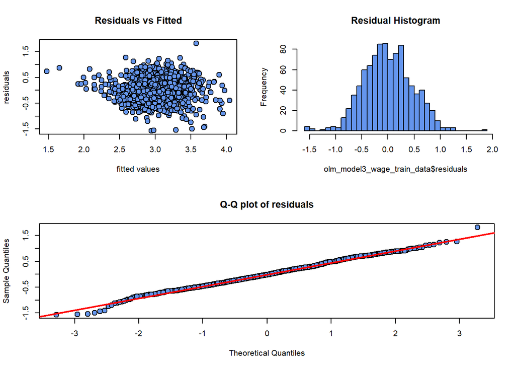

```r
# Define the plot layout matrix:
layout_mat <- matrix(c(1, 1, 2, 2, 3, 3, 3, 3),
                     nrow = 2, byrow = TRUE)
# print(layout_mat)
layout(layout_mat)
plot(olm_model3_wage_train_data$fitted.values, olm_model3_wage_train_data$residuals, type = "p",
     pch = 21, bg = "cornflowerblue", main = "Residuals vs Fitted",
     ylab = "residuals", xlab = "fitted values", cex = 1.5)
hist(olm_model3_wage_train_data$residuals, col = "cornflowerblue",
     breaks = 30, main = "Residual Histogram")
qqnorm(olm_model3_wage_train_data$residuals, main = "Q-Q plot of residuals",
       pch = 21, bg = "cornflowerblue", cex = 1.5)
qqline(olm_model3_wage_train_data$residuals, col = "red", lwd = 2)
```

En general de las gráficas del error del modelo MCO3 se observa que:

Residual vs. fitted plot: En el gráfico de residuos vs. valores ajustados, los residuos parecen tener una varianza constante, aunque hay algunos puntos que tienen valores de residuos grandes para valores ajustados bajos, pero esos puntos no constituyen la mayoría (la prueba de heterocedasticidad nos ayudará a determinar si su varianza es la misma en todas las observaciones).

Histograma de residuos: En el histograma de residuos, los residuos parecen ser normales, aunque el histograma parece tener una cola derecha un poco más larga.

Gráfico Q-Q de residuos: Los residuos en el gráfico Q-Q parecen caer a lo largo de una línea recta con los cuantiles teóricos de una distribución normal, excepto por un punto en el extremo derecho (que probablemente sea un valor atípico).

#### Test de Normalidad de los errores del modelo MCO3 (Test Jarque-Bera)

$$\begin{cases}
H_0&:\text{residuals follow a normal distribution}\\
H_1&:\text{residuals do not follow a normal distribution}
\end{cases}$$

```r
 tseries::jarque.bera.test(olm_model3_wage_train_data$residuals)
```

```
##
##  Jarque Bera Test
##
## data:  olm_model3_wage_train_data$residuals
## X-squared = 1.6395, df = 2, p-value = 0.4405
```

Esto indica que el aplicar la transformaciñon de logaritmo a la varible dependiente wage logró que se corrigiera la NO normalidad de los errores en el modelo MCO

#### Test de Homocedasticidad de errores del modelo MCO3 (Test Breusch-Pagan)

$$\begin{cases}
H_0&: \text{residuals are homoskedastic}\\
H_1&: \text{residuals are heteroskedastic}
\end{cases}$$

```r
# Breusch–Pagan Test

print(lmtest::bptest(olm_model3_wage_train_data))
```

```
##
##  studentized Breusch-Pagan test
##
## data:  olm_model3_wage_train_data
## BP = 19.258, df = 5, p-value = 0.001721
```

En este caso el valor de (sigue siendo) p< 0.05, por lo tanto rechazamos la hipótesis nula de que los residuos son homocedásticos. Esto significa que los residuos son heterocedásticos.

#### Test de Autocorrelación de Parcial errores del modelo MCO3

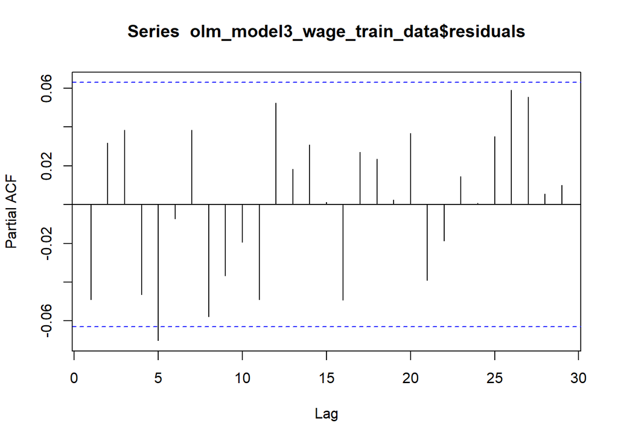

```r
pacf(olm_model3_wage_train_data$residuals)
```

Como podemos ver, no tenemos motivos para rechazar la hipótesis nula de autocorrelación en ninguno de los casos (excepto quizá para el error a lag 5)

A partir de estos resultados de la prueba, podemos concluir que los residuos no están autocorrelacionados

### Modelo MCO4 (removiendo las variables que no resultaron significatrivas en el MCO1 original que incluía todas las variables predictoras xi del conjunto de datos como variables predictoras + Logaritmo de variable dependiente wage como medida para lograr normalidad en error + Agregando la variable educ*female para evaluar el efecto de un aó de edicación dado que se es female)

Para construir el MCO4 se removerán las variables cuyos coeficientes p en la prueba t del modelo MCO1 sean mayores a 0.05, es decir las variables no significativas para el modelo MCO1, que en este caso eran: black, midwest y south. + Se agregó la variable female*educ Aedemás el modelo se hará tomadno como variable dependiente el log(wage)

```r
# Load libraries
library(stats)

# Fit linear model
olm_model4_wage_train_data <- lm(log(wage) ~ educ+exper+faminc+female+metro+ female*educ, data = wage_train_data)

# View model summary
summary(olm_model4_wage_train_data)
```

```
##
## Call:
## lm(formula = log(wage) ~ educ + exper + faminc + female + metro +
##     female * educ, data = wage_train_data)
##
## Residuals:
##      Min       1Q   Median       3Q      Max
## -1.60081 -0.32069 -0.01511  0.28818  1.84191
##
## Coefficients:
##               Estimate Std. Error t value Pr(>|t|)
## (Intercept)  1.360e+00  1.031e-01  13.183  < 2e-16 ***
## educ         9.858e-02  6.534e-03  15.087  < 2e-16 ***
## exper        7.885e-03  1.141e-03   6.908 8.94e-12 ***
## faminc       9.867e-07  3.296e-07   2.993 0.002830 **
## female      -4.752e-01  1.545e-01  -3.075 0.002165 **
## metro        1.380e-01  3.948e-02   3.496 0.000494 ***
## educ:female  1.779e-02  1.055e-02   1.687 0.091948 .
## ---
## Signif. codes:  0 '***' 0.001 '**' 0.01 '*' 0.05 '.' 0.1 ' ' 1
##
## Residual standard error: 0.4626 on 962 degrees of freedom
## Multiple R-squared:  0.3362, Adjusted R-squared:  0.3321
## F-statistic: 81.22 on 6 and 962 DF,  p-value: < 2.2e-16
```

#### El modelo General Lineal (GLR) o Modelo de Mínimos Cuadrados (MCG) GeneralizadoS

En general el modelo MCG asume los siguientes enunciados como ciertos:

A. Las variables xi predictoras son linealmente indpendientes entre si, por lo que la matriz X es de rango completo B. Los errores siguen una distribución normal
$${\varepsilon}\sim
N(\mathbf{0}, \sigma^2\Omega)$$

C. El valor esperado del error dado los valores de la matriz X es cero
$$\mathbb{E} \left(
\boldsymbol{\varepsilon} | \mathbf{X}\right) = \boldsymbol{0}$$
D. La varianza del error dado los valores de la matriz X puede calcularse como:

$$\mathbb{V}{\rm ar}\left(
\boldsymbol{\varepsilon} | \mathbf{X} \right)= \mathbb{E} \left(
\boldsymbol{\varepsilon} \boldsymbol{\varepsilon}^\top \right)$$
es decir,

$$\mathbb{V}{\rm ar}\left(
\boldsymbol{\varepsilon} | \mathbf{X} \right) = \mathbb{E} \left(
\boldsymbol{\varepsilon} \boldsymbol{\varepsilon}^\top \right)=
\boldsymbol{\Sigma} = \sigma_\epsilon^2 \mathbf{\Omega}$$

Donde ${\Omega}$ es una matriz cuadrada, simétrica y definida positiva de tamaño N × N. Este modelo permite que los errores sean heterocedásticos o autocorrelacionados (o ambos) y a menudo se denomina caso especial del modelo lineal generalizado (GLM).

Si ${\Omega}=I$, entonces el GMLR es simplemente el modelo de regresión lineal múltiple simple que discutimos al comienzo de este capítulo.

$${\Omega}= \begin{pmatrix}
1 & 0 & 0 & .. 0\\
0 & 1& 0 & .. 0\\
0 & 0& 1 & .. 0\\
0 & 0 & 0 & .. 1
\end{pmatrix}$$

Si ${\Omega}$ es diagonal con elementos diagonales no constantes, entonces los términos de error no están correlacionados pero son heterocedásticos.

$${\Omega}= \begin{pmatrix}
\omega_{1} & 0 & 0 & .. 0\\
0 & \omega_{2}& 0 & .. 0\\
0 & 0& \omega_{3} & .. 0\\
0 & 0 & 0 & .. \omega_{n}
\end{pmatrix}$$

Si ${\Omega}$ no es diagonal, entonces $Cov(\varepsilon_{i}, \varepsilon_{j})={\Omega_{ij}\neq 0}$ En econometría, las matrices de covarianza no diagonales se encuentran con mayor frecuencia en los datos de series temporales, con correlaciones más altas para las observaciones más cercanas en el tiempo (generalmente cuando i y j difieren en 1 o 2).

Si ${\Omega}$ no es diagonal y los elementos diagonales son constantes, entonces los errores están autocorrelacionados y homocedásticos.

$${\Omega}= \begin{pmatrix}
\sigma^{2} & \rho_{12} & \rho_{13} & ..\rho_{1N}\\
\rho_{21} & \sigma^{2}& \rho_{23} & ..\rho_{2N} \\
\rho_{31} & \rho_{32} & \sigma^{2} & ..\rho_{3N} \\
\rho_{41} & \rho_{42} & \rho_{43} & ..\sigma^{2}
\end{pmatrix}$$

Si ${\Omega}$ no es diagonal y los elementos diagonales no son constantes, entonces los errores están autocorrelacionados y heterocedásticos.

$${\Omega}= \begin{pmatrix}
\omega_{1} & \rho_{12} & \rho_{13} & ..\rho_{1N}\\
\rho_{21} & \omega_{2}& \rho_{23} & ..\rho_{2N} \\
\rho_{31} & \rho_{32} & \omega_{3} & ..\rho_{3N} \\
\rho_{41} & \rho_{42} & \rho_{43} & ..\omega_{N}
\end{pmatrix}$$

Y donde los estimadores ${\beta}$ del modelo lineal genralizado (GLS o MCG) puede ser calculado como :

$$\begin{aligned}
\widehat{\boldsymbol{\beta}_{GLS}} = \left( \mathbf{X}^\top
\mathbf{\Omega}^{-1} \mathbf{X}\right)^{-1} \mathbf{X}^\top
\mathbf{\Omega}^{-1} \mathbf{Y}
\end{aligned}$$

Y cuya función de minimización de error o función de costo a minimizar como función de los estimadores del modelo GLS es:

$$\left( \mathbf{Y} - \mathbf{X}
\boldsymbol{\beta} \right)^\top \mathbf{\Omega}^{-1} \left( \mathbf{Y} -
\mathbf{X} \boldsymbol{\beta} \right) \rightarrow
\min_{\boldsymbol{\beta}}$$

### Modelo MCG1 (correlacion del error 5)

```r
# Install 'nlme' package if you haven't already
#install.packages("nlme")

# Load the 'nlme' library
library(nlme)

# Fit genralized linear model
glm_1_wage_train_data <- gls(log(wage) ~ educ + exper + faminc + female + metro, correlation = corARMA(q = 5), method = "ML", data = wage_train_data)

# View model summary
summary(glm_1_wage_train_data)
```

```
## Generalized least squares fit by maximum likelihood
##   Model: log(wage) ~ educ + exper + faminc + female + metro
##   Data: wage_train_data
##        AIC      BIC    logLik
##   1262.902 1321.417 -619.4509
##
## Correlation Structure: ARMA(0,5)
##  Formula: ~1
##  Parameter estimate(s):
##      Theta1      Theta2      Theta3      Theta4      Theta5
## -0.05257651  0.04523000  0.03231570 -0.06379532 -0.06881414
##
## Coefficients:
##                  Value  Std.Error   t-value p-value
## (Intercept)  1.2497774 0.08779448 14.235261  0.0000
## educ         0.1060756 0.00522424 20.304498  0.0000
## exper        0.0081292 0.00111479  7.292151  0.0000
## faminc       0.0000010 0.00000033  3.016834  0.0026
## female      -0.2224369 0.02958459 -7.518676  0.0000
## metro        0.1395392 0.03881695  3.594801  0.0003
##
##  Correlation:
##        (Intr) educ   exper  faminc female
## educ   -0.846
## exper  -0.493  0.211
## faminc  0.011 -0.139  0.002
## female -0.034 -0.116  0.005 -0.059
## metro  -0.299 -0.079  0.034 -0.044 -0.026
##
## Standardized residuals:
##         Min          Q1         Med          Q3         Max
## -3.40054032 -0.70678320 -0.02897238  0.62929961  3.94417435
##
## Residual standard error: 0.4618932
## Degrees of freedom: 969 total; 963 residual
```

#### Prueba de hipotesis global para el modelo MCG1

Esta es la prueba de hipótesis conjunta para la significancia de múltiples coeficientes, aplicada a todos los coeficientes del modelo MCG:

$$\begin{cases}
H_0&: \beta_1 = \beta_2 = ... = \beta_k = 0 \\
H_1&: \beta_{j} \neq 0, \quad \text{for some } j
\end{cases}$$

```r
print(car::linearHypothesis(glm_1_wage_train_data, c("educ=0", "exper=0",  "faminc=0" ,  "female=0",  "metro=0")))
```

```
## Linear hypothesis test
##
## Hypothesis:
## educ = 0
## exper = 0
## faminc = 0
## female = 0
## metro = 0
##
## Model 1: restricted model
## Model 2: log(wage) ~ educ + exper + faminc + female + metro
##
##   Df  Chisq Pr(>Chisq)
## 1
## 2  5 505.87  < 2.2e-16 ***
## ---
## Signif. codes:  0 '***' 0.001 '**' 0.01 '*' 0.05 '.' 0.1 ' ' 1
```

Dado que el valor p es menor que 0.05 decido que tenemos sifuciente videncia para rechazar la HO y por lo tanto decir que los coeficientes $\beta$ del modelo MCG1 son diferentes de cero

#### Test de Normalidad de los errores del modelo GLM1 (Test Jarque-Bera)

$$\begin{cases}
H_0&:\text{residuals follow a normal distribution}\\
H_1&:\text{residuals do not follow a normal distribution}
\end{cases}$$

```r
 tseries::jarque.bera.test(glm_1_wage_train_data$residuals)
```

```
##
##  Jarque Bera Test
##
## data:  glm_1_wage_train_data$residuals
## X-squared = 1.8063, df = 2, p-value = 0.4053
```

No se tiene evidencia suficiente para rechazar la hipotesis nula del test JB por lo que se puede decir que los errores del modelo GLM1 siguen una distribución normal

#### Test de Homocedasticidad de errores del modelo GLM1 (Test Breusch-Pagan)

$$\begin{cases}
H_0&: \text{residuals are homoskedastic}\\
H_1&: \text{residuals are heteroskedastic}
\end{cases}$$

```r
# Breusch–Pagan Test

# Obtain residuals from the gls model
residuals_gls_1 <- residuals(glm_1_wage_train_data)

# Fit a linear regression model of squared residuals on the predictors
lm_resid_sq_1 <- lm(residuals_gls_1^2 ~ wage_train_data$educ + wage_train_data$exper + wage_train_data$faminc + wage_train_data$female + wage_train_data$metro)

# Perform the Breusch-Pagan test manually
lmtest::bptest(lm_resid_sq_1)
```

```
##
##  studentized Breusch-Pagan test
##
## data:  lm_resid_sq_1
## BP = 15.385, df = 5, p-value = 0.008838
```

En este caso el valor de (sigue siendo) p< 0.05, por lo tanto rechazamos la hipótesis nula de que los residuos son homocedásticos. Esto significa que los residuos para el modelo GLM1 siguen siendo heterocedásticos.

#### Test de Autocorrelación de Parcial errores del modelo GLM1

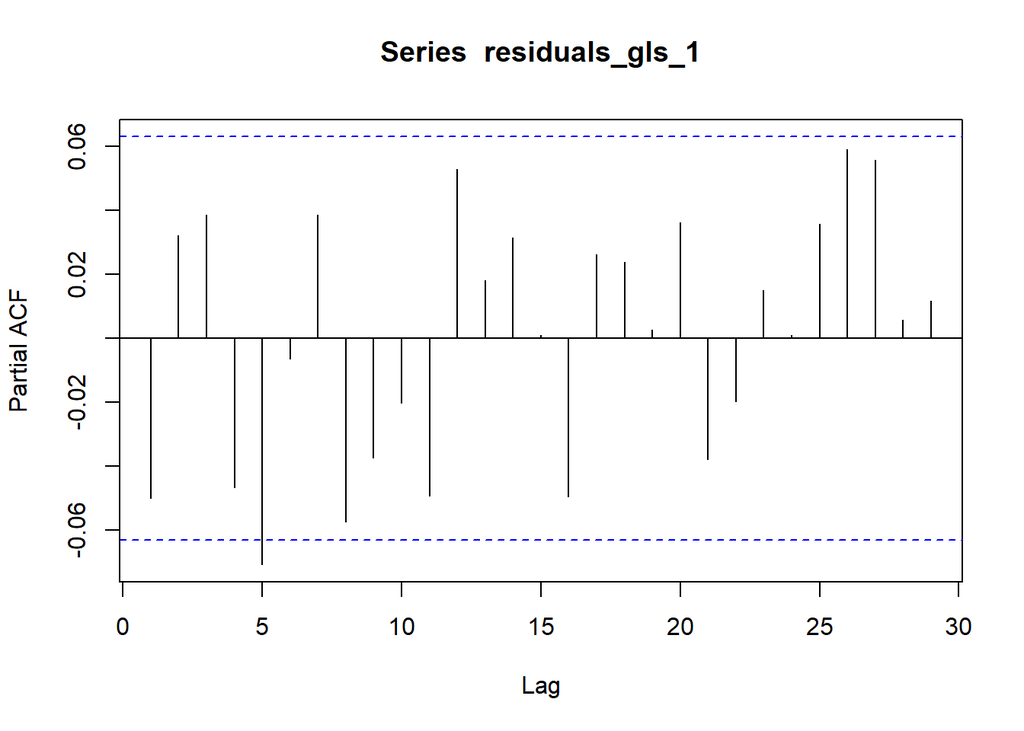

```r
pacf(residuals_gls_1)
```

Nos encontramos entonces en el caso donde los errores no están correlacionados pero son heterocerastico, es decir en donde nuestra matriz de covarianza del error es del tipo:

$${\Omega}= \begin{pmatrix}
\omega_{1} & 0 & 0 & .. 0\\
0 & \omega_{2}& 0 & .. 0\\
0 & 0& \omega_{3} & .. 0\\
0 & 0 & 0 & .. \omega_{n}
\end{pmatrix}$$

#### Tratamiento de heterocerasticidad en los errores.

Tras detectar heterocedasticidad en los errores, se quisieraimponer una estructura a la matriz de covarianza residual y estimar los coeficientes mediante GLS. Si sabemos que no existe correlación serial en los errores, entonces la covarianza es diagonal. Esto conduce a un caso específico de GLS: mínimos cuadrados ponderados (WLS).

En realidad, no conocemos la forma real de la heterocedasticidad. Por lo tanto, incluso sabiendo que la matriz de covarianza es diagonal, esto no nos dice nada sobre los elementos diagonales, que podrían ser cualquiera de los siguientes ejemplos:

$$\begin{aligned}
\mathbf{\Sigma} &= \sigma^2 \cdot \text{diag}\left(X_{j,1},
X_{j,2},..., X_{j,N} \right) \quad \\
\mathbf{\Sigma} &= \sigma^2 \cdot \text{diag}\left(X_{j,1}^2,
X_{j,2}^2,..., X_{j,N}^2 \right)\\
\mathbf{\Sigma} &= \sigma^2 \cdot \text{diag}\left(\sqrt{X_{j,1}},
\sqrt{X_{j,2}},..., \sqrt{X_{j,N}} \right), \text{ if } X_{j,i} \geq 0,\
\forall i = 1,...,N
\end{aligned}$$

Además, en una regresión múltiple, el patrón de heterocedasticidad puede depender de más de una variable explicativa; incluso podría estar relacionado con variables no incluidas en el modelo. Entonces, ¿cómo seleccionamos la forma más probable de heterocedasticidad?

Es a partir de los errores de los MCO que se obtiene una ponderación que sera el número que dividirá a todos los valores de covarianza heterocerasticos

$$\begin{aligned}
\sigma^2_i &= \exp\left( \alpha_0 + \alpha_1 Z_{1,i} + ... +
\alpha_m Z_{m,i} \right)\\
&= \sigma^2 \exp\left(\alpha_1 Z_{1,i} + ... + \alpha_m Z_{m,i}
\right),\ \text{ where } \exp\left( \alpha_0 \right) = \sigma^2
\end{aligned}$$

Modelar la varianza como una función exponencial de algunas variables explicativas (como α0+α1Z1,i+…+αmZm,i) sugiere una forma funcional para explicar las varianzas variables.

Inicialmente, σi2=exp(α0+α1Z1,i+…+αmZm,i) define la varianza (σi2) como una función exponencial de los predictores (Z1,i,Z2,i,…,Zm,i) con parámetros (α0,α1,…,αm).

Tomar logaritmos de ambos lados y agregar/eliminar el residuo de OLS da como resultado:

$$\log(\sigma^2_i) = \alpha_0 + \alpha_1
Z_{1,i} + ... + \alpha_m Z_{m,i} \pm
\log(\widehat{\epsilon}^2_i)$$

Tomar logaritmos de ambos lados de la ecuación ayuda a linealizar la relación. Convierte la relación multiplicativa entre la varianza y los predictores en una aditiva.

Esto conduce a log(σi2)=α0+α1Z1,i+…+αmZm,i.

Agregar o eliminar los residuos de OLS (Ordinary Least Squares) de la ecuación produce log(ϵi2)=α0+α1Z1,i+…+αmZm,i±log(ϵi2/σi2).

Esto se puede simplificar como:

$$\begin{aligned}
\log(\widehat{\epsilon}^2_i) &= \alpha_0 + \alpha_1 Z_{1,i} + ... +
\alpha_m Z_{m,i} + \log \left(
\dfrac{\widehat{\epsilon}^2_i}{\sigma^2_i} \right)\\
&= \alpha_0 + \alpha_1 Z_{1,i} + ... + \alpha_m Z_{m,i} + v_i
\end{aligned}$$

Esta ecuación se simplifica a log(ϵi2)=α0+α1Z1,i+…+αmZm,i+vi, donde vi es un término de error introducido.

El término de error introducido vi captura la diferencia entre la varianza real y la varianza predicha por el modelo.

Se estiman los coeificentes (α0,α1,…,αm) usando MCO para cuantificar como los predictores (Z1,i,Z2,i,…,Zm,i) se relacionan con la variabilidad de los reisduales

Las propiedades de este modelo dependen de las propiedades del término de error introducido vi. En muestras más grandes, se espera que este término de error sea más cercano a lo que esperamos del término de error (homocedástico con media cero).

### El procedimiento del método de GLS ó MCG para el caso de errores heterocerasticos

1. Llevar a cabo la regesion $\mathbf{Y} = \mathbf{X} \boldsymbol{\beta} + \boldsymbol{\varepsilon}$ usando los MCO
2. Usar los residuos de los MCO $\widehat{\boldsymbol{\varepsilon}}_{OLS}$ como $\log(\epsilon_i^2)$
3. Calcular $\log(\epsilon_i^2) = \alpha_0 + \alpha_1 Z_{1,i} + ... + \alpha_m Z_{m,i} + v_i$

En la práctica, utilizamos las mismas variables del conjunto $\mathbf{X}$, a menos que sepamos con certeza que existen variables explicativas adicionales que podrían determinar la heterocedasticidad.

4. Se calcula el valor de la variable hi que se usará como una espeice de “ponderador” de varianzas que tiene como intención hacer de dichas varianzas heterocerasticas, lo más homocerasticas posibles, en este caso, lo mas cercanas y parecidas a la unidad

$$\widehat{h}_i =
\exp\left(\widehat{\log(\epsilon_i^2)}\right)$$

5. Se Llevaa a cabo de nuevo la regesion $\mathbf{Y} = \mathbf{X} \boldsymbol{\beta} + \boldsymbol{\varepsilon}$ usando ahora WLS

$$\omega_i^{-1} =
1/\sqrt{\widehat{h}_i}$$

$$\mathbf{\Psi}^\top = \mathbf{\Psi} =
\text{diag}\left( 1/\sqrt{\widehat{h}_1}, ...,
1/\sqrt{\widehat{h}_N}\right)$$

Lo que implica que nuestro modelo ahora es del tipo:

$$Y_i / \sqrt{\widehat{h}_i} = \beta_0
\cdot \left(1/\sqrt{\widehat{h}_i} \right) + \beta_1 \cdot \left(X_{1,i}
/ \sqrt{\widehat{h}_i} \right) + ... + \beta_k \cdot \left(X_{k,i} /
\sqrt{\widehat{h}_i} \right) +
\epsilon_i/\sqrt{\widehat{h}_i}$$

Nuestro modelo ya no contiene una constante -β0 ahora se usa para la nueva variable (no constante) $1/\sqrt{\widehat{h}_i} \neq 1$

#### Weighted Least Square (WLS) para tratar temas de herocerasticidad de errores (MCO1)

Entonces se calculan los
$$\log(\epsilon_i^2)$$
:

```r
# Extract residuals from the model
residuals_model_mco1 <- residuals(olm_model1_wage_train_data)

residuals_model_mco1_dataframe <- data.frame(log_e2 = log(residuals_model_mco1^2), wage_train_data$educ, wage_train_data$exper, wage_train_data$faminc, wage_train_data$female, wage_train_data$metro)

head(residuals_model_mco1_dataframe)
```

```
##     log_e2 wage_train_data.educ wage_train_data.exper wage_train_data.faminc
## 1 6.257489                   13                    45                      0
## 2 3.106942                   14                    25                  45351
## 3 5.925431                   18                    27                  91946
## 6 4.139139                   16                    26                 151308
## 7 5.397745                   16                    11                 110461
## 9 5.521513                   21                    32                  67084
##   wage_train_data.female wage_train_data.metro
## 1                      1                     1
## 2                      1                     1
## 3                      1                     1
## 6                      1                     1
## 7                      1                     1
## 9                      0                     1
```

```r
dim(residuals_model_mco1_dataframe)
```

```
## [1] 969   6
```

```r
log_e2 = log(residuals_model_mco1^2)
length(log_e2)
```

```
## [1] 969
```

Y se crea el modelo lineal de los log de errores

$$\begin{aligned}
\log(\widehat{\epsilon}^2_i) &= \alpha_0 + \alpha_1 Z_{1,i} + ... +
\alpha_m Z_{m,i} + \log \left(
\dfrac{\widehat{\epsilon}^2_i}{\sigma^2_i} \right)\\
&= \alpha_0 + \alpha_1 Z_{1,i} + ... + \alpha_m Z_{m,i} + v_i
\end{aligned}$$

```r
residual_linear_model_mco1<- lm(log_e2 ~  wage_train_data$educ+ wage_train_data$exper+wage_train_data$faminc+wage_train_data$female+wage_train_data$metro, data = residuals_model_mco1_dataframe)

residual_linear_model_mco1
```

```
##
## Call:
## lm(formula = log_e2 ~ wage_train_data$educ + wage_train_data$exper +
##     wage_train_data$faminc + wage_train_data$female + wage_train_data$metro,
##     data = residuals_model_mco1_dataframe)
##
## Coefficients:
##            (Intercept)    wage_train_data$educ   wage_train_data$exper
##              3.532e-02               1.935e-01               1.882e-02
## wage_train_data$faminc  wage_train_data$female   wage_train_data$metro
##              4.492e-06              -6.129e-01               4.279e-01
```

```r
length(residual_linear_model_mco1$fitted.values)
```

```
## [1] 969
```

Y se calcula el “factor de corrección de heterocerasticidad” $\omega_i^{-1} = 1/\sqrt{\widehat{h}_i}$

$$\widehat{h}_i =
\exp\left(\widehat{\log(\epsilon_i^2)}\right)$$

```r
h_est_model_mco1 <- exp(residual_linear_model_mco1$fitted.values)
length(h_est_model_mco1)
```

```
## [1] 969
```

Se arma el data frame para aplicar el “factor de corrección de heterocerasticidad” $\omega_i^{-1} = 1/\sqrt{\widehat{h}_i}$

Es decir:
$$Y_i / \sqrt{\widehat{h}_i} =
\beta_0 \cdot \left(1/\sqrt{\widehat{h}_i} \right) + \beta_1 \cdot
\left(X_{1,i} / \sqrt{\widehat{h}_i} \right) + ... + \beta_k \cdot
\left(X_{k,i} / \sqrt{\widehat{h}_i} \right) +
\epsilon_i/\sqrt{\widehat{h}_i}$$

Y entonces se necesita formar el data frame

$$Y_i = \ (X_{1,i}) + \ (X_{2,i}), ... \
+ (X_{k,i})$$

```r
data_mat_glm_1_wage_train_data <- data.frame(glm_1_wage_train_data$fitted, wage_train_data$educ,
    wage_train_data$exper,  wage_train_data$faminc ,wage_train_data$female, wage_train_data$metro)

head(data_mat_glm_1_wage_train_data)
```

```
##   glm_1_wage_train_data.fitted wage_train_data.educ wage_train_data.exper
## 1                     2.911678                   13                    45
## 2                     2.899763                   14                    25
## 3                     3.386141                   18                    27
## 6                     3.224231                   16                    26
## 7                     3.062127                   16                    11
## 9                     3.943003                   21                    32
##   wage_train_data.faminc wage_train_data.female wage_train_data.metro
## 1                      0                      1                     1
## 2                  45351                      1                     1
## 3                  91946                      1                     1
## 6                 151308                      1                     1
## 7                 110461                      1                     1
## 9                  67084                      0                     1
```

Agregando el $\beta_0$
$$Y_i = \beta_0 + \ (X_{1,i}) + \ (X_{2,i}), ... \
+ (X_{k,i})$$

```r
data_weighted_glm_1_wage_train_data = data.frame(data_mat_glm_1_wage_train_data / sqrt(h_est_model_mco1), weighted_intercept = 1 / sqrt(h_est_model_mco1))

head(data_weighted_glm_1_wage_train_data)
```

```
##   glm_1_wage_train_data.fitted wage_train_data.educ wage_train_data.exper
## 1                    0.5840758             2.607769              9.026894
## 2                    0.5756781             2.779363              4.963148
## 3                    0.4034788             2.144807              3.217211
## 6                    0.4118728             2.043887              3.321317
## 7                    0.4937588             2.579952              1.773717
## 9                    0.2609764             1.389931              2.117990
##   wage_train_data.faminc wage_train_data.female wage_train_data.metro
## 1                  0.000              0.2005976             0.2005976
## 2               9003.350              0.1985259             0.1985259
## 3              10955.914              0.1191560             0.1191560
## 6              19328.530              0.1277429             0.1277429
## 7              17811.503              0.1612470             0.1612470
## 9               4440.102              0.0000000             0.0661872
##   weighted_intercept
## 1          0.2005976
## 2          0.1985259
## 3          0.1191560
## 6          0.1277429
## 7          0.1612470
## 9          0.0661872
```

```r
dim(data_weighted_glm_1_wage_train_data)
```

```
## [1] 969   7
```

Calculando el “factor de corrección de heterocerasticidad”

$$\omega_i^{-1} =
1/\sqrt{\widehat{h}_i}$$

```r
weighted_intercept = 1 / sqrt(h_est_model_mco1)
length(weighted_intercept)
```

```
## [1] 969
```

```r
weights_varFunc <- varFixed(~ 1/h_est_model_mco1)
weights_varFunc
```

```
## Variance function structure of class varFixed with no parameters, or uninitialized
```

```r
weights_varFunc
```

```
## Variance function structure of class varFixed with no parameters, or uninitialized
```

### Modelo MCG2_2 (correlacion del error 5 + tratamiento de heterocerasticidad de errores)

```r
# Assuming data_mat_glm_1_wage_train_data is properly constructed
data_weighted_glm_1_wage_train_data <- data.frame(
  fitted = data_mat_glm_1_wage_train_data[, 1],  # Assuming the first column is 'fitted'
  educ = wage_train_data$educ,
  exper = wage_train_data$exper,
  faminc = wage_train_data$faminc,
  female = wage_train_data$female,
  metro = wage_train_data$metro
)
data_weighted_glm_1_wage_train_data$weighted_intercept <- 1 / sqrt(h_est_model_mco1)

# Check the structure and head of data_weighted_glm_1_wage_train_data again
str(data_weighted_glm_1_wage_train_data)
```

```
## 'data.frame':    969 obs. of  7 variables:
##  $ fitted            : num  2.91 2.9 3.39 3.22 3.06 ...
##  $ educ              : int  13 14 18 16 16 21 14 12 12 12 ...
##  $ exper             : int  45 25 27 26 11 32 12 40 43 23 ...
##  $ faminc            : int  0 45351 91946 151308 110461 67084 14000 25000 0 0 ...
##  $ female            : int  1 1 1 1 1 0 0 0 0 1 ...
##  $ metro             : int  1 1 1 1 1 1 0 1 1 1 ...
##  $ weighted_intercept: num  0.201 0.199 0.119 0.128 0.161 ...
```

```r
head(data_weighted_glm_1_wage_train_data)
```

```
##     fitted educ exper faminc female metro weighted_intercept
## 1 2.911678   13    45      0      1     1          0.2005976
## 2 2.899763   14    25  45351      1     1          0.1985259
## 3 3.386141   18    27  91946      1     1          0.1191560
## 4 3.224231   16    26 151308      1     1          0.1277429
## 5 3.062127   16    11 110461      1     1          0.1612470
## 6 3.943003   21    32  67084      0     1          0.0661872
```

```r
glm_2_2_wage_train_data <- gls(log(fitted) ~ educ + exper + faminc + female + metro,
                                weights = weights_varFunc,
                                correlation = corARMA(q = 5),
                                method = "ML",
                                data = data_weighted_glm_1_wage_train_data)


summary(glm_2_2_wage_train_data)
```

```
## Generalized least squares fit by maximum likelihood
##   Model: log(fitted) ~ educ + exper + faminc + female + metro
##   Data: data_weighted_glm_1_wage_train_data
##         AIC       BIC   logLik
##   -6353.684 -6295.169 3188.842
##
## Correlation Structure: ARMA(0,5)
##  Formula: ~1
##  Parameter estimate(s):
##       Theta1       Theta2       Theta3       Theta4       Theta5
## -0.030175175  0.043996721  0.002196260 -0.003728772  0.009687675
## Variance function:
##  Structure: fixed weights
##  Formula: ~1/h_est_model_mco1
##
## Coefficients:
##                  Value    Std.Error   t-value p-value
## (Intercept)  0.5487098 0.0017306261  317.0586       0
## educ         0.0331170 0.0000917902  360.7907       0
## exper        0.0024943 0.0000198162  125.8722       0
## faminc       0.0000003 0.0000000036   80.3960       0
## female      -0.0683669 0.0005451215 -125.4159       0
## metro        0.0451754 0.0008450870   53.4565       0
##
##  Correlation:
##        (Intr) educ   exper  faminc female
## educ   -0.814
## exper  -0.432  0.127
## faminc  0.026 -0.159  0.068
## female -0.079 -0.046  0.043 -0.002
## metro  -0.368 -0.093  0.049 -0.061  0.010
##
## Standardized residuals:
##        Min         Q1        Med         Q3        Max
## -7.8493394 -0.4336473  0.1538907  0.5627460  1.8240008
##
## Residual standard error: 0.05129724
## Degrees of freedom: 969 total; 963 residual
```

```r
print(round(coef(summary(glm_2_2_wage_train_data)), 5))
```

```
##                Value Std.Error    t-value p-value
## (Intercept)  0.54871   0.00173  317.05855       0
## educ         0.03312   0.00009  360.79073       0
## exper        0.00249   0.00002  125.87217       0
## faminc       0.00000   0.00000   80.39604       0
## female      -0.06837   0.00055 -125.41585       0
## metro        0.04518   0.00085   53.45647       0
```

#### Calculando los residuos del modelo MCG2_2 (aplicando el escalado de matriz de varianza)

```r
errors_mcg2_2 <- 1 / sqrt(h_est_model_mco1) * glm_2_2_wage_train_data$residuals
head(errors_mcg2_2,5)
```

```
##             1             2             3             6             7
##  8.947373e-05 -1.403209e-05  4.751575e-04  8.253821e-04  6.718875e-04
```

```r
length(errors_mcg2_2)
```

```
## [1] 969
```

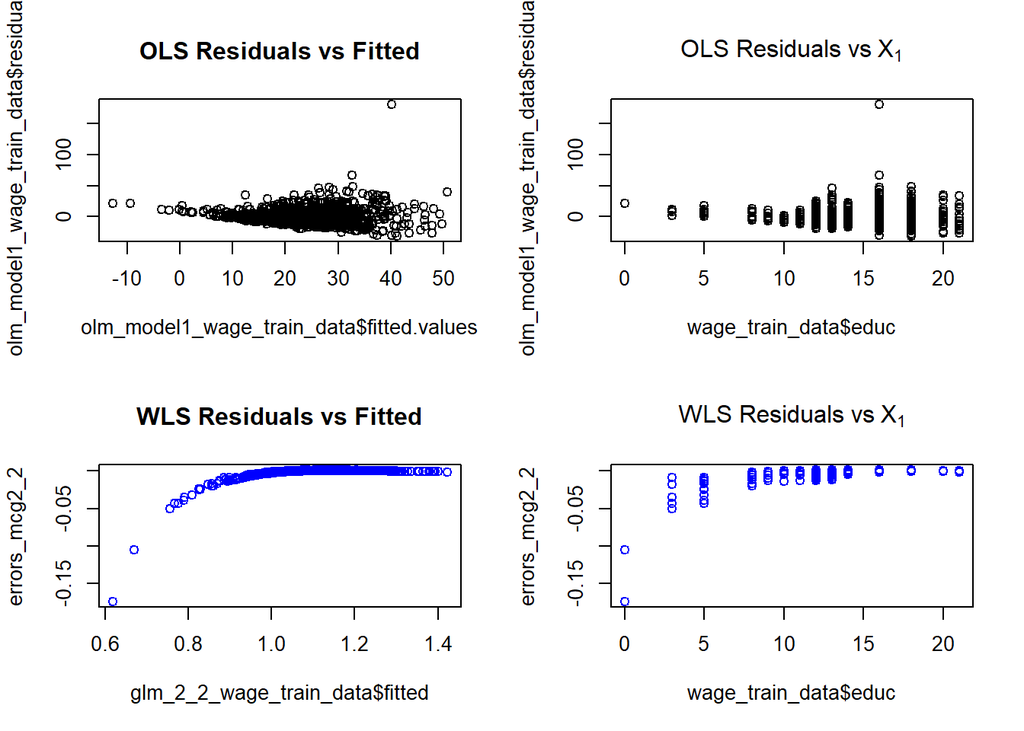

```r
par(mfrow = c(2, 2))

#
plot(olm_model1_wage_train_data$fitted.values, olm_model1_wage_train_data$residuals, main = "OLS Residuals vs Fitted")

#
plot(wage_train_data$educ, olm_model1_wage_train_data$residuals, main = bquote("OLS Residuals vs"~X[1]))

#
plot(glm_2_2_wage_train_data$fitted, errors_mcg2_2, col = "blue", main = "WLS Residuals vs Fitted")

#
plot(wage_train_data$educ, errors_mcg2_2, col = "blue", main = bquote("WLS Residuals vs"~X[1]))
```

Observamos claramente que la magnitud de los residuos del modelo GLM2_2/MCG2_2 es menor que el MCO1.

#### Test de Homocedasticidad de errores del modelo GLM2_2 (Test Breusch-Pagan)

$$\begin{cases}
H_0&: \text{residuals are homoskedastic}\\
H_1&: \text{residuals are heteroskedastic}
\end{cases}$$

residuals_gls son los residuos obtenidos de su modelo gls. lm_resid_sq ajusta un modelo de regresión lineal donde los residuos al cuadrado se regresan a los predictores (los mismos predictores utilizados en su modelo original). Finalmente, se utiliza la función bptest de lmtest para realizar la prueba de Breusch-Pagan en este modelo de regresión.

```r
# Breusch–Pagan Test

# Obtain residuals from the gls model
residuals_gls_2_2 <- residuals(glm_2_2_wage_train_data)

# Fit a linear regression model of squared residuals on the predictors
lm_resid_sq_2_2 <- lm(residuals_gls_2_2^2 ~ wage_train_data$educ + wage_train_data$exper + wage_train_data$faminc + wage_train_data$female + wage_train_data$metro)

# Perform the Breusch-Pagan test manually
lmtest::bptest(lm_resid_sq_2_2)
```

```
##
##  studentized Breusch-Pagan test
##
## data:  lm_resid_sq_2_2
## BP = 40.819, df = 5, p-value = 1.021e-07
```

## Bibliografía

https://ocw.mit.edu/courses/18-650-statistics-for-applications-fall-2016/2c0395a301a2ca798b1c0ee18cf6eedc_MIT18_650F16_Regression.pdf

https://ocw.mit.edu/courses/18-650-statistics-for-applications-fall-2016/dff89368051a5feae72b39c6422d0752_MIT18_650F16_GLM.pdf

https://web.vu.lt/mif/a.buteikis/wp-content/uploads/PE_Book/4-6-Multiple-GLS.html